# Practical Machine Learning - Course Project

Chris Eagle

14 September 2015

# Introduction

The goal of the project is to correctly predict the way in which a barbell is lifted, correctly and incorrectly using data from accelerometers on the belt, forearm, arm, and dumbell of 6 participants. Details of the Weight Lifting Exercise can be found here http://groupware.les.inf.puc-rio.br/har.

# Setup

Training and test data were downloaded from the following locations and saved to the working directory. The training data: https://d396qusza40orc.cloudfront.net/predmachlearn/pml-training.csv

The test data: https://d396qusza40orc.cloudfront.net/predmachlearn/pml-testing.csv

Loading the caret package, enabling multi-core processing and setting the seed:

```r
library(caret)
library(doParallel)
cl<-makeCluster(detectCores())
registerDoParallel(cl)
set.seed(62334)
```

```r
training<-read.csv("pml-training.csv",na.strings=c("NA","#DIV/0!"))
TrainIndex<-createDataPartition(training$classe,p=0.75)[[1]]
training<-training[TrainIndex,]
validation<-training[-TrainIndex,]
```

# Feature Selection

The dataset provided has 160 variables, including details of the participant and time windows where the data was captured. In addition, there is the raw output from each of the accelerometers, and related summary statistics (e.g. max, min, st dev.). If the raw data is to be included, then the summary statistics are effectively a ‘double count’ - they can be observed from the raw data. e.g. the ‘max’ value will be included as one of the raw data points. Secondly, the summary data is, logically, less numerous than the raw data, so not enough data points to train on. Hence, summary statistics excluded.

```r
col_names<-names(training)
exclude<-c("X","user_name","timestamp","window","kurtosis","skewness","min",
           "max","amplitude","var","stddev","avg")

exclude_cols<-NULL
for (i in exclude){
  exclude_cols<-c(exclude_cols,grep(i,col_names))
}

training<-training[-exclude_cols]
validation<-validation[-exclude_cols]
```

# Model Fitting

```r
tc<-trainControl(method='cv',number=5,repeats=5)
```

For comparison, I fitted both ‘boosting’ and ‘random forest’ models and compared the accuracy.

Boosted Tree:

```r
ModelFit_gbm<-train(classe~.,method="gbm",data=training,trControl=tc)
prediction_gbm<-predict(ModelFit_gbm,validation)
confusionMatrix(validation$classe,prediction_gbm)
```

```
## Confusion Matrix and Statistics
##
##           Reference
## Prediction    A    B    C    D    E
##          A 1037    6    3    0    0
##          B   18  699   10    1    0
##          C    0   17  597    5    3
##          D    1    2   15  593    0
##          E    0    3    3    8  661
##
## Overall Statistics
##
##                Accuracy : 0.9742
##                  95% CI : (0.9686, 0.9791)
##     No Information Rate : 0.2868
##     P-Value [Acc > NIR] : < 2.2e-16
##
##                   Kappa : 0.9674
##  Mcnemar's Test P-Value : NA
##
## Statistics by Class:
##
##                      Class: A Class: B Class: C Class: D Class: E
## Sensitivity            0.9820   0.9615   0.9506   0.9769   0.9955
## Specificity            0.9966   0.9902   0.9918   0.9941   0.9954
## Pos Pred Value         0.9914   0.9602   0.9598   0.9705   0.9793
## Neg Pred Value         0.9928   0.9905   0.9899   0.9954   0.9990
## Prevalence             0.2868   0.1974   0.1706   0.1649   0.1803
## Detection Rate         0.2816   0.1898   0.1621   0.1611   0.1795
## Detection Prevalence   0.2841   0.1977   0.1689   0.1659   0.1833
## Balanced Accuracy      0.9893   0.9758   0.9712   0.9855   0.9954
```

Random Forest:

```r
ModelFit_rf<-train(classe~.,method="rf",data=training,trControl=tc)
prediction_rf<-predict(ModelFit_rf,validation)
confusionMatrix(validation$classe,prediction_rf)
```

```
## Confusion Matrix and Statistics
##
##           Reference
## Prediction    A    B    C    D    E
##          A 1046    0    0    0    0
##          B    0  728    0    0    0
##          C    0    0  622    0    0
##          D    0    0    0  611    0
##          E    0    0    0    0  675
##
## Overall Statistics
##
##                Accuracy : 1
##                  95% CI : (0.999, 1)
##     No Information Rate : 0.2841
##     P-Value [Acc > NIR] : < 2.2e-16
##
##                   Kappa : 1
##  Mcnemar's Test P-Value : NA
##
## Statistics by Class:
##
##                      Class: A Class: B Class: C Class: D Class: E
## Sensitivity            1.0000   1.0000   1.0000   1.0000   1.0000
## Specificity            1.0000   1.0000   1.0000   1.0000   1.0000
## Pos Pred Value         1.0000   1.0000   1.0000   1.0000   1.0000
## Neg Pred Value         1.0000   1.0000   1.0000   1.0000   1.0000
## Prevalence             0.2841   0.1977   0.1689   0.1659   0.1833
## Detection Rate         0.2841   0.1977   0.1689   0.1659   0.1833
## Detection Prevalence   0.2841   0.1977   0.1689   0.1659   0.1833
## Balanced Accuracy      1.0000   1.0000   1.0000   1.0000   1.0000
```

# Model Selection and Error Estimation

The Random Forest Model has a slightly higher accuracy than the Boosted Tree, so this is selected as the final model.

```r
OOB1<-round(ModelFit_rf$finalModel[4][[1]][1]*100,2)
OOB500<-round(ModelFit_rf$finalModel[4][[1]][500]*100,2)
```

The out of bag error estimate goes from 7.55 for the first tree, to 0.72 for 500 trees.

# Variable Importance

“Roll_belt” scores highest in terms of variable importance:

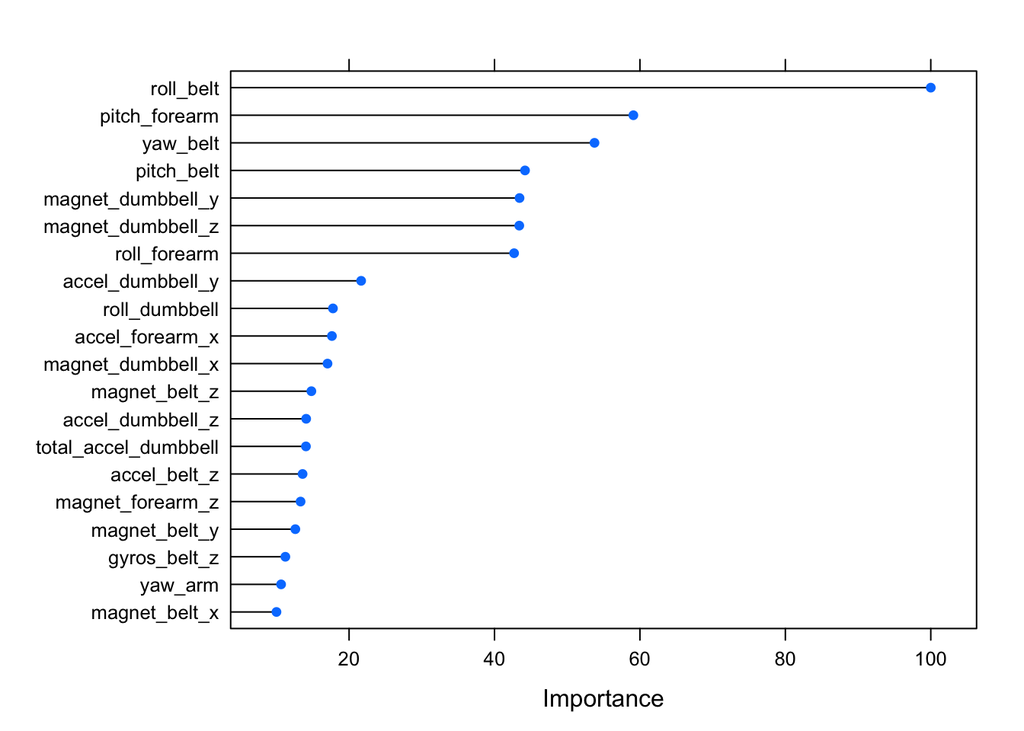

```r
variable_imp<-varImp(ModelFit_rf)
plot(variable_imp,top=20)
```

# Predicting against the Test Set

The Random Forest Model is then used to predict against the test dataset.

```r
testing<-read.csv("pml-testing.csv")

answers<-predict(ModelFit_rf,testing)
```

# Export

The results are then exported using the following code.

```r
pml_write_files = function(x){
  n = length(x)
  for(i in 1:n){
    filename = paste0("problem_id_",i,".txt")
    write.table(x[i],file=filename,quote=FALSE,row.names=FALSE,col.names=FALSE)
  }
}

pml_write_files(answers)
```